# Building a Travel Demand Model for the Oklahoma City Metropolitan Statistical Area

Gabe Barrett-Jackson, Matt Khinda, Samantha Page

2023-02-23

# Introduction + Demographics

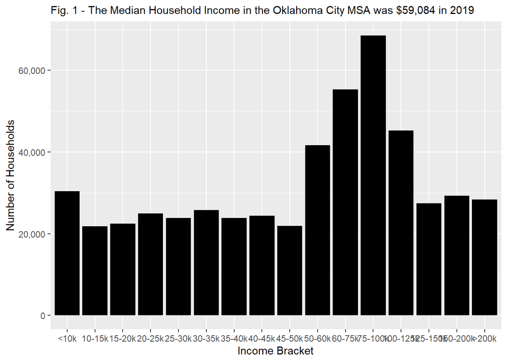

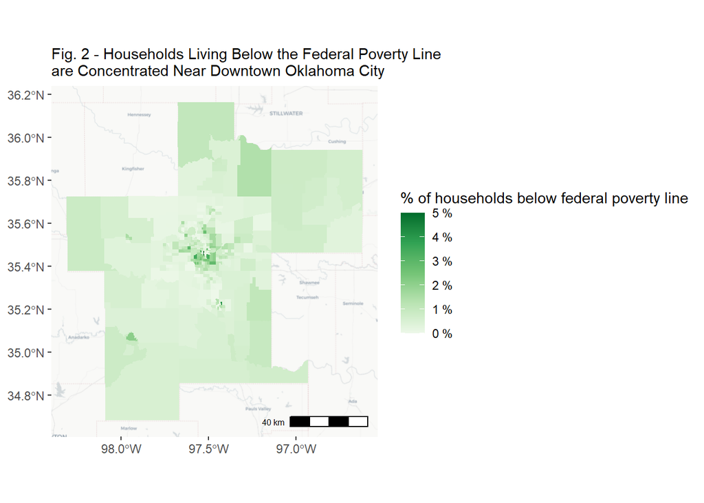

# Transportation in OKC

EMBARK, the area’s transit authority, operates all public transit in greater Oklahoma City, which includes fixed-route bus service, the OKC Streetcar, paratransit service, river ferry transit, and a bikeshare network. Beyond transit, car-ownership and use is prevalent in the Oklahoma City MSA with only 2.6% of households reporting that they do not have access to a vehicle (Fig. 3), and a median number of vehicles per household of 2.3. According to the 2019 ACS 5-Year Estimates, cars, trucks, or vans are the most common means of transportation to work for workers 16 and over (used by 92.6% of respondents), while commuting by public transportation is far less common (used by 0.5% of respondents). Based on the same ACS data, the average travel time to work is 23 minutes.

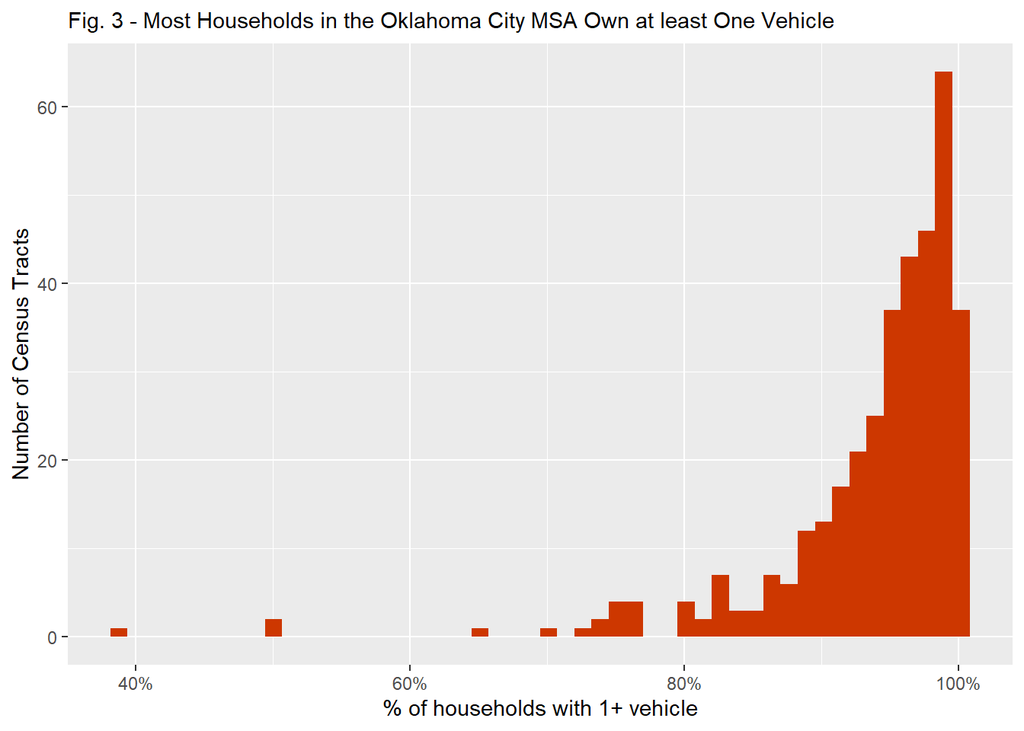

## Road Network

The Oklahoma City MSA contains a road network that has developed akin to many cities in the United States. Downtown OKC, which is the oldest part of the MSA, largely follows a grid pattern. As the network moves towards the periphery this street network design changes. The network becomes much more sparse and transitions to a less uniform curvilinear network.

## Road Network Summary Statistics

Road classifications are determined by Open Street Maps, from which we extracted our road network.

- Primary roads: 438.3 miles
- Secondary roads: 982.2 miles
- Tertiary roads: 1550.4 miles
- Trunk roads: 299.0 miles
- Links/Centroid Connectors: 3306.2 miles

# Our Model

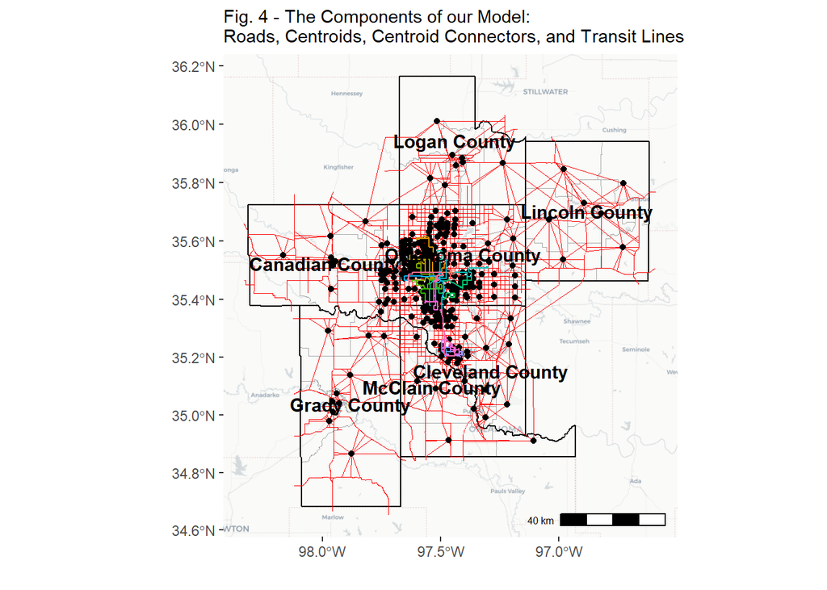

To create the network in TransCAD (Fig. 4), we imported the Open Street Maps layer and selected for primary, secondary, tertiary, and trunk roads. When creating the centroids and centroid connectors, we allowed for the connectors to extend outside of zone boundaries, at up to 30 miles, and up to 10 connectors per centroid. This resulted in a matrix with only a few gaps, which we resolved by turning surrounding roads two-way. (The major roads in the area were separated highways, so we trust that two-way driving is actually feasible in these zones.)

Assumptions that were incorporated into our road network include:

- Vehicle speed on primary roads is: 60 mph
- Vehicle speed on secondary roads is: 40 mph
- Vehicle speed on tertiary roads is: 30 mph
- Vehicle speed on trunk roads is: 60 mph
- Vehicle speed on link/centroid connectors is: 15 mph

Assumptions that were incorporated into our model when we created our transit network include:

- Everyone walks to transit
- Transit vehicle speed is 23 mph
- Walking speed is 2.5 mph
- There is an assumed 15-minute wait time, max wait time, and transfer time
- Fares are $2 and there is a $0 transfer fee
- EMBARK operates a streetcar which was changed in TransCAD to exist as rail

The charts below illustrate how the timing of various transit trips break down across walk, wait, transfer and travel time (Figs. 5-6).

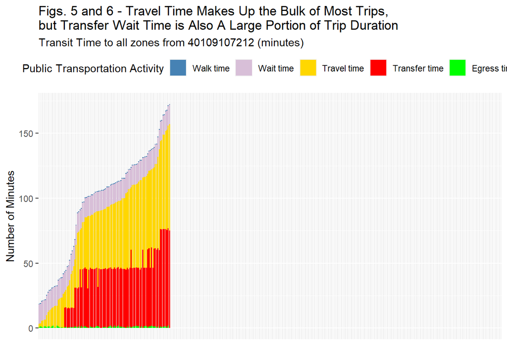

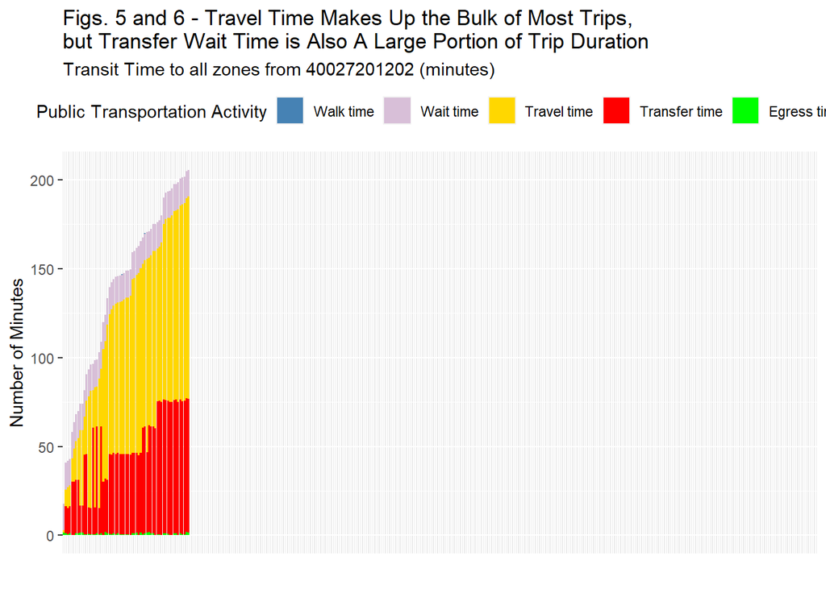

# Land Use: Employment & Population Density

Major employment sectors in the Oklahoma City metro area include government, higher education, aerospace, healthcare, and retail. According to the Greater Oklahoma City Chamber of Commerce, major employers include the State of Oklahoma, Tinker Air Force Base, the University of Oklahoma, Integris Health, and Amazon. In 2021, the metropolitan area added 10,825 jobs (1.7% increase), and further job growth was expected in 2022 as stated in the 2022 Greater Oklahoma City Economic Outlook.

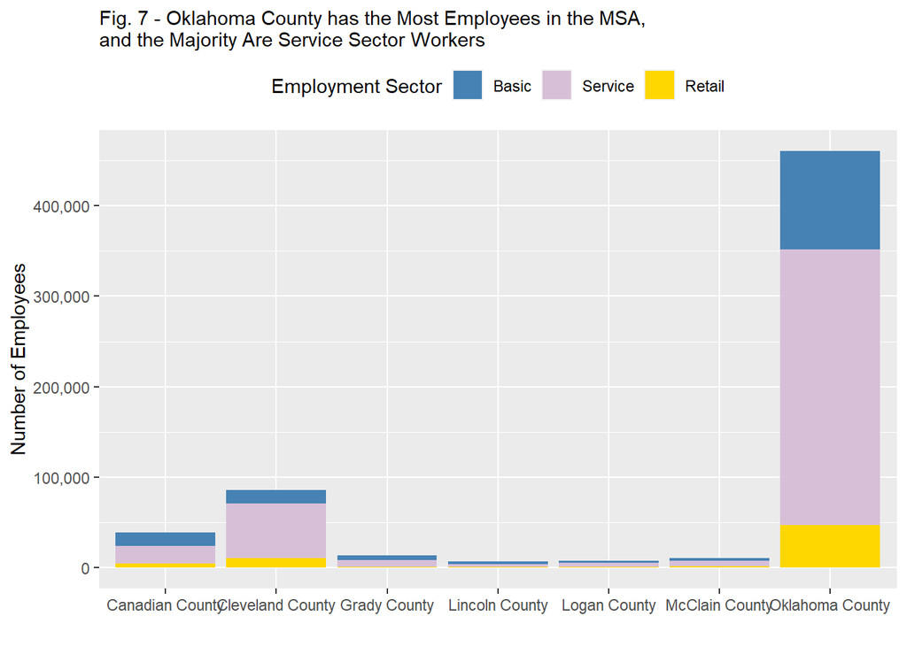

OKC generally follows a monocentric pattern of development with the greatest density of people living and working in downtown Oklahoma City (Figs. 8 and 9), located in the center of the MSA.

This employment density aligns with heightened public transit connectivity, too. In the urban core of Oklahoma City, we notice an overlap between a central business district, higher employment density, and increased public transit connectivity.

[figure not shown]

[figure not shown]

# Accessiblity

The measurement of accessibility has been suggested as the ultimate benchmark for evaluating the effectiveness of land-use and transportation systems. By gauging accessibility, one can evaluate how much certain demographic groups benefit from a particular land-use and transportation system. This analysis can yield a significant socio-spatial report for urban planners, informing them on how to better plan and implement these systems (El-Geneidy and Levinson 2022; Wachs and Kumagai 1973).

When we first completed our road network skim, we created a visualization of accessibility based on drive-time access from one zone to all others (Fig. 10). This metric allowed us to compare the relative accessibility of tracts more easily. This zonal-based accessibility shows connectivity as opposed to an index metric, as illustrated below, and assumes that all zones are equally valuable, rather than weighting zones based on the amenities or activities accessible within them. It also relies on a rigid threshold to determine accessibility: determining an “accessibility score” by counting the number of zones each origin could reach within 30 minutes of driving. We note that this score is affected by the lack of residential roads in our network, which would likely provide better accessibility for some of the peripheral zones.

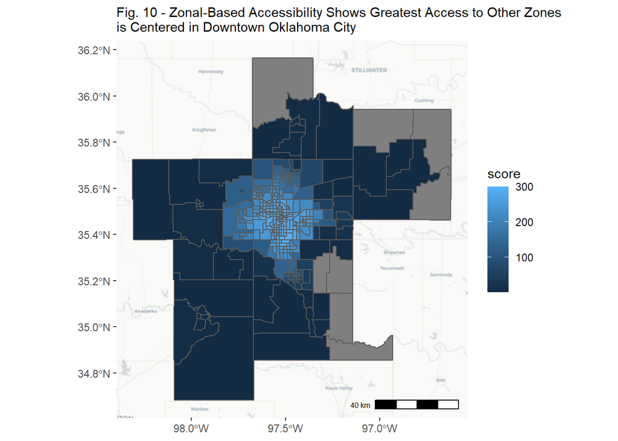

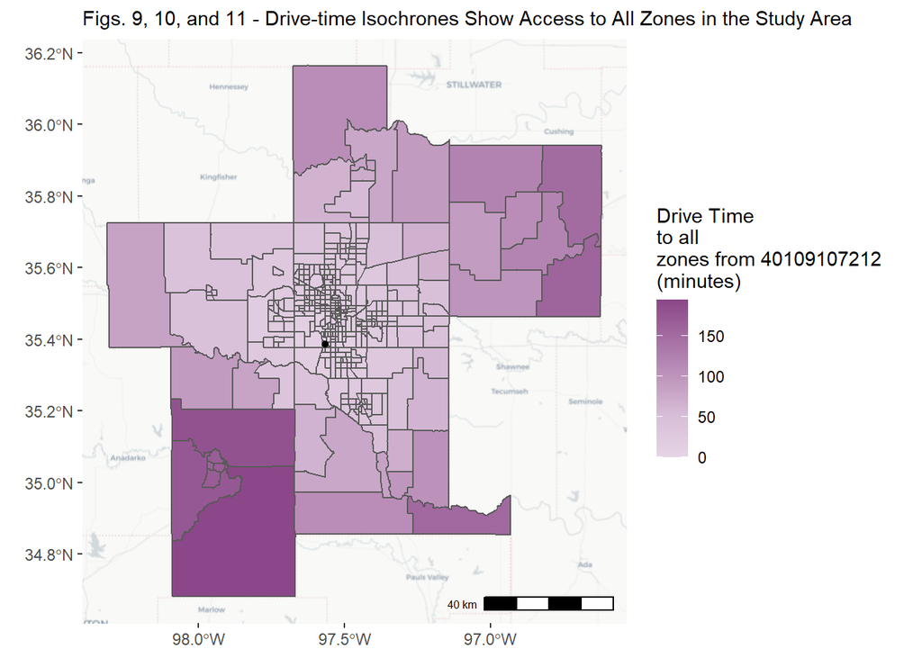

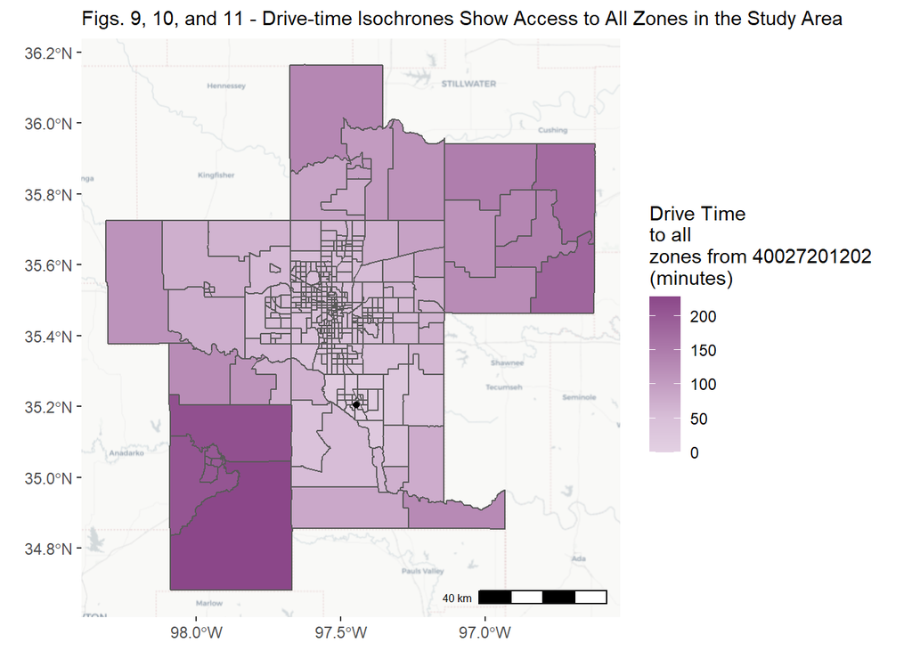

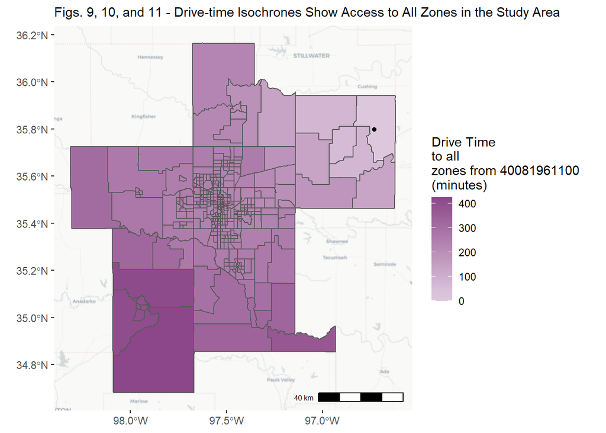

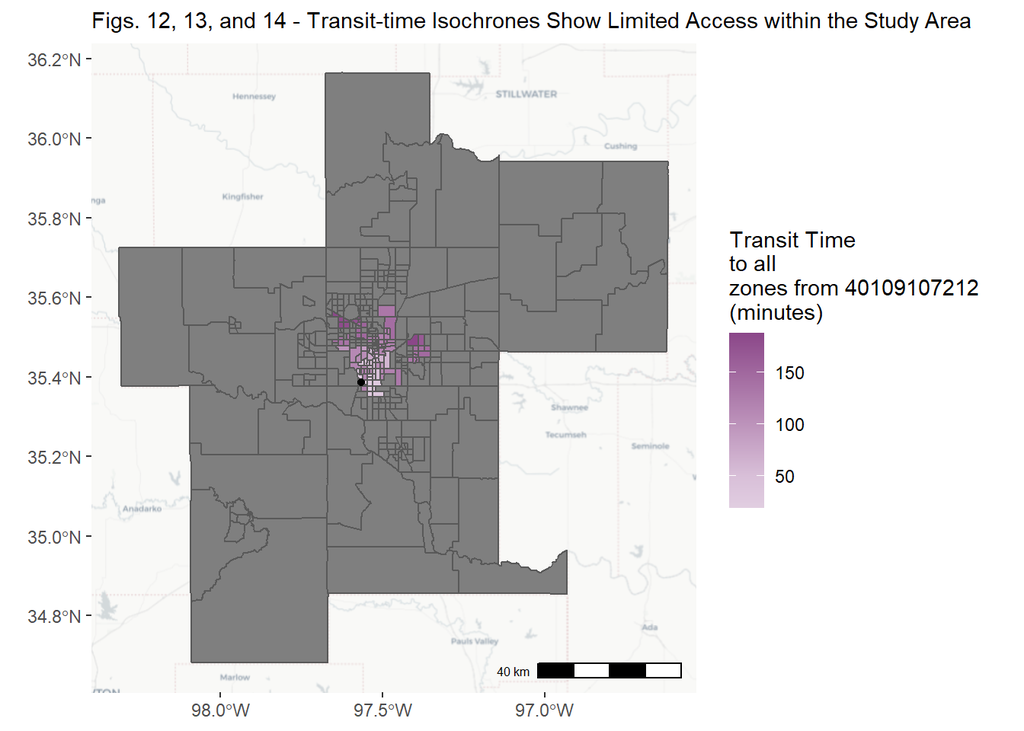

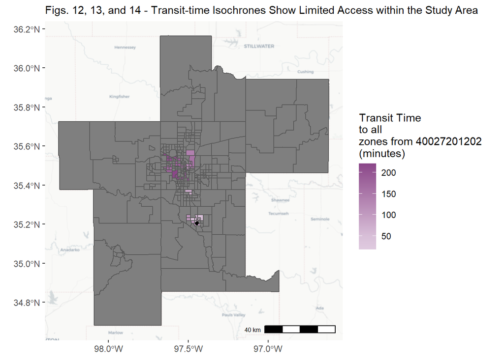

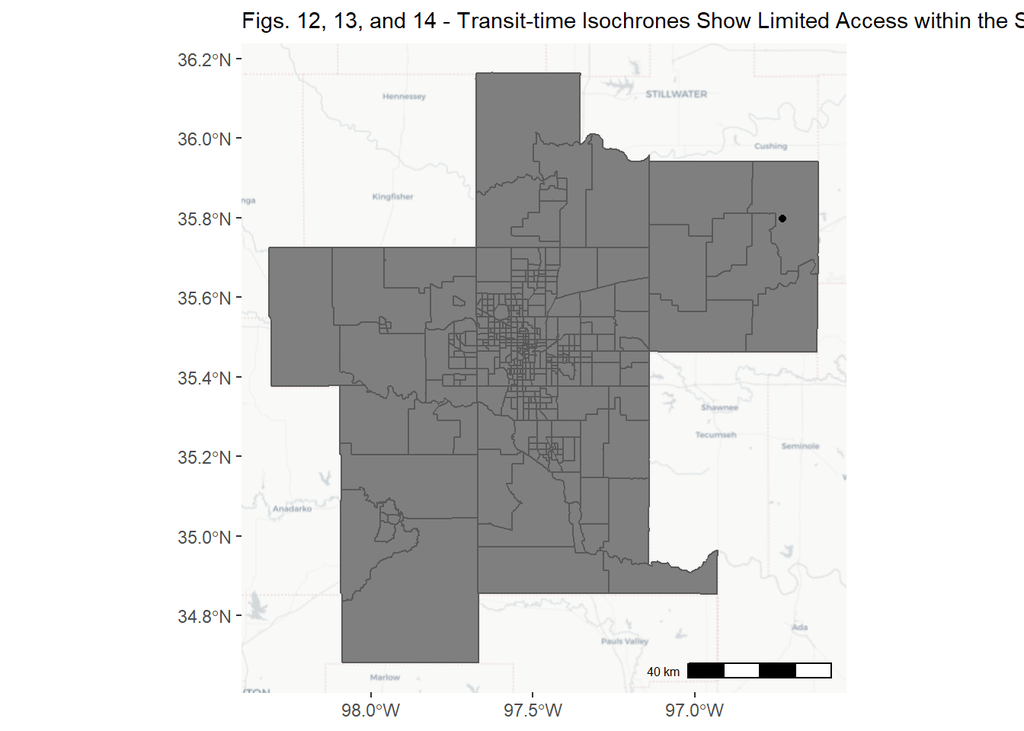

After calculating and creating our initial visualization of zonal-based accessibility we came to understand that the number of zones one can reach is less relevant than the number of opportunities one can reach. Our definition of accessibility also changed to reflect this understanding. We turn to the definition provided by Carole, accessibility: The ease with which a person can fully participate in the economic, civic, and social life of their society. In the case of our model we have chosen to limit accessibility to access to job opportunities. Our model still holds assumptions, for example, zones are assigned value based on what the jobs they contain. In this way we employ a gravity-based accessibility measure that considers the attractiveness and distance of destinations within a particular area. This measure considers that the more attractive a destination is and the closer it is to a particular location, the more accessible it is to people living or working in that area.

We have decided to keep measures of car and transit accessibility separate, rather than create a combined metric of the two (Figs. 15-16). We are more interested in comparing access across the two different modes than conceptualizing one measure of both car and transit accessibility. However, we did weight transit travel time to account for perceptions that out-of-vehicle travel time on public transportation trips is more onerous than in-vehicle travel time, multiplying OVTT by 1.5.

For our models, we selected the exponential function for car travel and the logistic function for transit travel (Figs. 17-18). Our rationale is that the exponential function captures the long-reaching value of a private vehicle in achieving accessibility, as the measure of accessibility never quite reaches 0, no matter how long the travel time. The benefit of a logistic function for transit, however, reflects the perception of great access within short trips on a transit network. For both functions, we set a half-life/inflection point of 30 minutes, which aligns with our personal conceptions of reasonable work- and personal-trip distances.

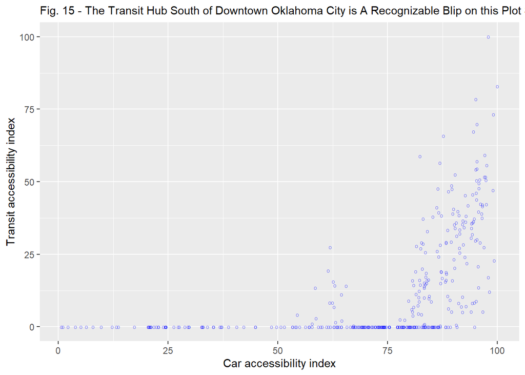

[figure not shown]

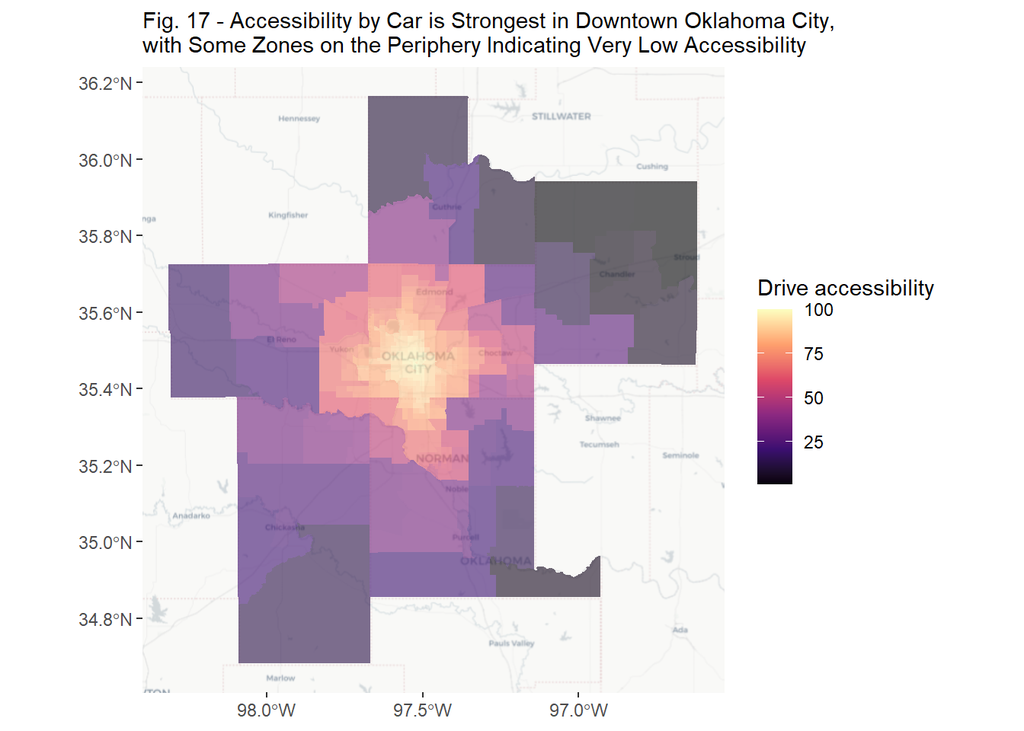

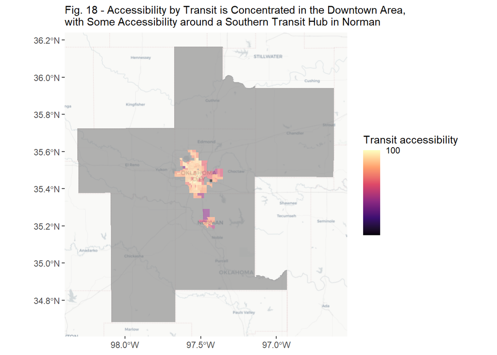

# Technical appendix

## Data dictionary

### Overview of data structures

| GEOID | NAME | tot_popE | no_vehE | total_hhsE | hh_1personE | hh_2personE | hh_3personE | hh_4person_plusE | hh_u18_married_coupleE | hh_u18_singleparent_maleE | hh_u18_singleparent_femaleE | hh_65plusE | tot_disabledE | inc_lt_10kE | inc_btw_10k_15kE | inc_btw_15k_20kE | inc_btw_20k_25kE | inc_btw_25k_30kE | inc_btw_30k_35kE | inc_btw_35k_40kE | inc_btw_40k_45kE | inc_btw_45k_50kE | inc_btw_50k_60kE | inc_btw_60k_75kE | inc_btw_75k_100kE | inc_btw_100k_125kE | inc_btw_125k_150kE | inc_btw_150k_200kE | inc_gt_200kE | … |
| --- | --- | --- | --- | --- | --- | --- | --- | --- | --- | --- | --- | --- | --- | --- | --- | --- | --- | --- | --- | --- | --- | --- | --- | --- | --- | --- | --- | --- | --- | --- |
| 40027202007 | Census Tract 2020.07, Cleveland County, Oklahoma | 4371 | 6 | 1540 | 334 | 509 | 167 | 530 | 1028 | 51 | 169 | 270 | 4293 | 0 | 80 | 65 | 25 | 10 | 41 | 38 | 139 | 94 | 163 | 143 | 389 | 175 | 51 | 68 | 59 | … |
| 40109107217 | Census Tract 1072.17, Oklahoma County, Oklahoma | 2043 | 22 | 702 | 199 | 131 | 157 | 215 | 302 | 54 | 265 | 202 | 2043 | 39 | 73 | 66 | 40 | 66 | 90 | 27 | 5 | 14 | 125 | 105 | 45 | 0 | 7 | 0 | 0 | … |
| 40109103602 | Census Tract 1036.02, Oklahoma County, Oklahoma | 581 | 0 | 8 | 0 | 8 | 0 | 0 | 0 | 0 | 0 | 4 | 581 | 0 | 4 | 0 | 0 | 4 | 0 | 0 | 0 | 0 | 0 | 0 | 0 | 0 | 0 | 0 | 0 | … |
| 40027202002 | Census Tract 2020.02, Cleveland County, Oklahoma | 4021 | 0 | 2019 | 795 | 794 | 255 | 175 | 320 | 8 | 136 | 551 | 3955 | 84 | 141 | 64 | 60 | 156 | 101 | 71 | 40 | 39 | 230 | 457 | 255 | 143 | 71 | 42 | 65 | … |
| 40027201508 | Census Tract 2015.08, Cleveland County, Oklahoma | 3238 | 9 | 1370 | 534 | 436 | 164 | 236 | 505 | 6 | 219 | 340 | 3113 | 70 | 8 | 36 | 97 | 171 | 55 | 131 | 64 | 24 | 124 | 158 | 117 | 93 | 79 | 63 | 80 | … |
| 40017301008 | Census Tract 3010.08, Canadian County, Oklahoma | 6832 | 0 | 1990 | 202 | 699 | 384 | 705 | 1467 | 168 | 27 | 510 | 6832 | 71 | 10 | 9 | 19 | 71 | 75 | 10 | 104 | 45 | 128 | 155 | 240 | 347 | 250 | 256 | 200 | … |

| from_GEOID | to_GEOID | drive_time | total_time_mins | num_transfers | access_wt | init_wt | ivtt | transfer_wt | egress_wt | ovtt | perceived_time | fare | total_emp | basic_emp | service_emp | retail_emp | geometry | weight_drive | weight_transit | drive_jobs | transit_jobs |
| --- | --- | --- | --- | --- | --- | --- | --- | --- | --- | --- | --- | --- | --- | --- | --- | --- | --- | --- | --- | --- | --- |
| 40027202007 | 40109107217 | 19.17474 | NA | NA | NA | NA | NA | NA | NA | NA | NA | NA | 291 | 29 | 236 | 26 | POLYGON ((-97.54794 35.4207… | 0.6420876 | NA | 186.8475 | NA |
| 40027202007 | 40109103602 | 19.97458 | NA | NA | NA | NA | NA | NA | NA | NA | NA | NA | 988 | 395 | 540 | 53 | POLYGON ((-97.53013 35.4632… | 0.6303306 | NA | 622.7666 | NA |
| 40027202007 | 40027202002 | 13.36041 | NA | NA | NA | NA | NA | NA | NA | NA | NA | NA | 1138 | 506 | 484 | 148 | POLYGON ((-97.52126 35.3771… | 0.7344076 | NA | 835.7559 | NA |
| 40027202007 | 40027201508 | 25.63375 | NA | NA | NA | NA | NA | NA | NA | NA | NA | NA | 1612 | 48 | 1050 | 514 | POLYGON ((-97.51263 35.2038… | 0.5530730 | NA | 891.5536 | NA |
| 40027202007 | 40017301008 | 31.53315 | NA | NA | NA | NA | NA | NA | NA | NA | NA | NA | 796 | 216 | 566 | 14 | POLYGON ((-97.70691 35.4496… | 0.4825984 | NA | 384.1483 | NA |
| 40027202007 | 40109108221 | 42.48836 | NA | NA | NA | NA | NA | NA | NA | NA | NA | NA | 542 | 179 | 302 | 61 | POLYGON ((-97.56721 35.6967… | 0.3746775 | NA | 203.0752 | NA |

## Code

### Stacked Bar Generator

```
transit_stackedbar_generator <- function(iso_origin){
  temp_matrix <- full_travel_matrix %>%
  filter(from_GEOID == iso_origin) %>%
  select(to_GEOID, access_wt, init_wt, ivtt, transfer_wt, egress_wt)

temp_matrix_stacked <- melt(temp_matrix, id = "to_GEOID")

ggplot(temp_matrix_stacked, aes(x = reorder(to_GEOID, value), y = value, fill = variable)) +
  geom_bar(stat = "identity") +
  scale_fill_manual(values = c("steelblue","thistle", "gold", "red", "green"), label = c("Walk time", "Wait time", "Travel time", "Transfer time", "Egress time")) +
  scale_y_continuous(labels = scales::comma) +
  labs(y = "Number of Minutes", x = " ", fill = "Public Transportation Activity", title = paste("Transit Time to all zones from", iso_origin, "(minutes)"))  +
    labs(subtitle = "Figs. 15 and 16 - Travel Time Makes Up the Bulk of Most Trips,\nbut Transfer Wait Time is Also A Large Portion of Trip Duration") +
  theme(legend.position = "top", axis.text.x=element_blank(), axis.ticks.x=element_blank())
}
```

### Isochrone Generator

```
drive_isochrone_generator <- function(iso_origin){
  temp_matrix <- full_travel_matrix %>%
  filter(from_GEOID == iso_origin)

  #get tract geometry from ok_msa
iso_drivetime_from_origin <- full_tract_info %>%
  select(GEOID, geometry) %>%
  full_join(temp_matrix, by = c("GEOID" = "to_GEOID"))

selected_centroid <- full_centroid_geom %>%
  filter(GEOID == iso_origin)

#change NA to 0
iso_drivetime_from_origin[is.na(iso_drivetime_from_origin)] <- 0

ggplot(iso_drivetime_from_origin) +
  annotation_map_tile(zoomin = 0, progress = "none", type = "cartolight") +
  geom_sf(aes(fill = drive_time)) +
  scale_fill_gradient2(low = "white", mid = "thistle", high = "orchid4",
                       midpoint = 50, #median(iso_drivetime_from_origin$travel_time_mins),
                       name = paste("Drive Time\nto all\nzones from", iso_origin, "\n(minutes)")) +
  labs(subtitle = "Figs. 9, 10, and 11 - Drive-time Isochrones Show Access to All Zones in the Study Area") +
  geom_sf(data = selected_centroid, shape = 19, size = 1.5) +
  annotation_scale(location = 'br', text_cex = 0.5) +
  theme()
}

transit_isochrone_generator <- function(iso_origin){
  temp_matrix <- full_travel_matrix %>%
  filter(from_GEOID == iso_origin)

  #get tract geometry from ok_msa
iso_transittime_from_origin <- full_tract_info %>%
  select(GEOID, geometry) %>%
  full_join(temp_matrix, by = c("GEOID" = "to_GEOID"))

selected_centroid <- full_centroid_geom %>%
  filter(GEOID == iso_origin)

ggplot(iso_transittime_from_origin) +
  annotation_map_tile(zoomin = 0, progress = "none", type = "cartolight") +
  geom_sf(aes(fill = total_time_mins)) +
  scale_fill_gradient2(low = "white", mid = "thistle", high = "orchid4",
                       midpoint = 50, #median(iso_drivetime_from_origin$travel_time_mins),
                       name = paste("Transit Time\nto all\nzones from", iso_origin, "\n(minutes)")) +
  labs(subtitle = "Figs. 12, 13, and 14 - Transit-time Isochrones Show Limited Access within the Study Area") +
  geom_sf(data = selected_centroid, shape = 19, size = 1.5) +
  annotation_scale(location = 'br', text_cex = 0.5) +
  theme()
}
```

### Cumulative Accessibility

```
drive_accessibility_matrix <- full_travel_matrix %>%
  filter(drive_time<30) %>%
  group_by(from_GEOID) %>%
  tally() %>%
  rename(score = n)

drive_accessibility_geom <- full_tract_info %>%
  select(GEOID, geometry) %>%
  left_join(drive_accessibility_matrix,
            by = c("GEOID" = "from_GEOID"))

ggplot(drive_accessibility_geom) +
  annotation_map_tile(zoomin = 0, progress = "none", type = "cartolight") +
  geom_sf(aes(fill=score)) +
  labs(subtitle = "Fig. 8 - Zonal-Based Accessibility Shows Greatest Access to Other Zones\nis Centered in Downtown Oklahoma City") +
  annotation_scale(location = 'br', text_cex = 0.5) +
  theme()
```

### Gravity-based Accessibility Functions

```
accessibility_summary <- accessibility_summary %>%
  left_join(full_tract_info %>%
              select(GEOID, geometry),
            by = c("from_GEOID" = "GEOID")) %>%
  as.data.frame()

tract_accessibility <- full_tract_info %>%
  select(GEOID, geometry) %>%
  left_join(accessibility_summary,
            by = c("GEOID" = "from_GEOID"))

ggplot(tract_accessibility) +
  annotation_map_tile(type = "cartolight",
                      zoomin = 0,
                      progress = "none") +
  geom_sf(aes(fill = drive_index),
          color = NA,
          alpha = 0.6) +
  scale_fill_viridis_c(name = "Drive accessibility",
                       #trans = "log",
                       #breaks = c(0.000001,100),
                       #labels = c("Low",
                                  #"High"),
                       option = "A") +
  labs(subtitle = "Fig. 19 - Accessibility by Car is Strongest in Downtown Oklahoma City,\nwith Some Zones on the Periphery Indicating Very Low Accessibility") +
  theme()

ggplot(tract_accessibility) +
  annotation_map_tile(type = "cartolight",
                      zoomin = 0,
                      progress = "none") +
  geom_sf(aes(fill = transit_index),
          color = NA,
          alpha = 0.6) +
  scale_fill_viridis_c(name = "Transit accessibility",
                       trans = "log",
                       breaks = c(0.000001,100),
                       #labels = c("Low",
                                  #"High"),
                       option = "A") +
  labs(subtitle = "Fig. 20 - Accessibility by Transit is Concentrated in the Downtown Area,\nwith Some Accessibility around a Southern Transit Hub in Norman") +
  theme()
```